# Fast Metric Kernel Density Estimation for Outlier Detection

This notebook demonstrates fast metric kernel density estimation (KDE) for nonparametric outlier detection in structural health monitoring. The fast metric KDE approach uses tree-based algorithms that significantly speed up density estimation for large datasets while allowing custom distance metrics.

## Overview

Fast metric kernel density estimation provides:

- **Nonparametric modeling**: No assumptions about underlying data distribution
- **Tree-based speedup**: O(N log N) complexity instead of O(N²)
- **Custom metrics**: Support for various distance metrics beyond Euclidean
- **Scalability**: Efficient for large datasets common in SHM applications

## Theory

Kernel density estimation approximates the probability density function as:

$$\hat{f}(x) = \frac{1}{nh^d} \sum_{i=1}^{n} K\left(\frac{d(x, x_i)}{h}\right)$$

where:

- $K$ is the kernel function
- $h$ is the bandwidth parameter
- $d(x, x_i)$ is the distance metric between points
- $n$ is the number of training samples
- $d$ is the data dimensionality

The fast implementation uses kd-trees or ball-trees to efficiently find nearby points, reducing computational complexity.

```python
# Import required libraries
import numpy as np
import matplotlib.pyplot as plt
from pathlib import Path
import sys

# Add shmtools to Python path
notebook_dir = Path.cwd()
shmtools_dir = notebook_dir.parent.parent.parent
if str(shmtools_dir) not in sys.path:
    sys.path.insert(0, str(shmtools_dir))

print(f"Working directory: {notebook_dir}")
print(f"SHMTools directory: {shmtools_dir}")

# Import SHMTools functions
from shmtools.utils.data_loading import load_3story_data
from shmtools.features import ar_model_shm
from shmtools.classification import (
    learn_fast_metric_kernel_density_shm,
    score_fast_metric_kernel_density_shm,
    learn_kernel_density_shm,
    score_kernel_density_shm,
)

# Set random seed for reproducibility
np.random.seed(42)

# Configure matplotlib
plt.style.use('seaborn-v0_8-darkgrid')
plt.rcParams['figure.figsize'] = (10, 6)
plt.rcParams['font.size'] = 12
```

```
Working directory: /Users/eric/repo/shm/shmtools-python/examples/notebooks/advanced
SHMTools directory: /Users/eric/repo/shm/shmtools-python
```

## Load and Prepare Data

We'll use the 3-story structure dataset and extract AR model features for outlier detection.

```python
# Load the 3-story structure data
try:
    data = load_3story_data()
    dataset = data['dataset']
    fs = data['fs']
    damage_states = data['damage_states']
    print(f"Dataset shape: {dataset.shape}")
    print(f"Sampling frequency: {fs} Hz")
    print(f"Number of damage states: {len(np.unique(damage_states))}")
except FileNotFoundError as e:
    print(f"Error: {e}")
    print("\nPlease download the example datasets and place them in the 'examples/data/' directory.")
    print("See examples/data/README.md for instructions.")
    raise
```

```
Dataset shape: (8192, 5, 170)
Sampling frequency: 2000.0 Hz
Number of damage states: 17
```

## Feature Extraction

Extract AR model parameters as features for damage detection.

```python
# Extract channels 2-5 (accelerometers)
accelerations = dataset[:, 1:, :]  # Skip channel 0 (force)
print(f"Accelerations shape: {accelerations.shape}")

# Extract AR features
ar_order = 15
ar_features, rmse_features, _, _, _ = ar_model_shm(accelerations, ar_order)
print(f"AR features shape: {ar_features.shape}")
```

```
Accelerations shape: (8192, 4, 170)
```

```
AR features shape: (170, 60)
```

## Data Splitting

Split data into training (undamaged) and testing (undamaged + damaged) sets.

```python
# Identify undamaged and damaged conditions
# States 1-9: undamaged baseline conditions
# States 10-17: various damage scenarios
undamaged_idx = damage_states <= 9
damaged_idx = damage_states > 9

# Split undamaged data for training/testing
undamaged_features = ar_features[undamaged_idx]
n_undamaged = len(undamaged_features)
n_train = int(0.8 * n_undamaged)

# Random shuffle for train/test split
shuffle_idx = np.random.permutation(n_undamaged)
train_features = undamaged_features[shuffle_idx[:n_train]]
test_undamaged = undamaged_features[shuffle_idx[n_train:]]
test_damaged = ar_features[damaged_idx]

# Combine test sets
test_features = np.vstack([test_undamaged, test_damaged])
test_labels = np.concatenate([np.zeros(len(test_undamaged)),
                              np.ones(len(test_damaged))])

print(f"Training samples: {len(train_features)}")
print(f"Test samples: {len(test_features)} ({len(test_undamaged)} undamaged, {len(test_damaged)} damaged)")
```

```
Training samples: 72
Test samples: 98 (18 undamaged, 80 damaged)
```

## Fast Metric KDE vs Standard KDE

Compare fast metric KDE with standard KDE in terms of computation time and accuracy.

```python
import time

# Train standard KDE model
print("Training standard KDE model...")
start_time = time.time()
standard_kde_model = learn_kernel_density_shm(train_features, bs_method=2)
standard_train_time = time.time() - start_time
print(f"Standard KDE training time: {standard_train_time:.3f} seconds")

# Train fast metric KDE model with different bandwidths
bandwidths = [0.1, 0.5, 1.0, 2.0]
fast_kde_models = {}

for bw in bandwidths:
    print(f"\nTraining fast metric KDE with bandwidth={bw}...")
    start_time = time.time()
    fast_kde_models[bw] = learn_fast_metric_kernel_density_shm(
        train_features, bw=bw, kernel='gaussian', metric='euclidean'
    )
    fast_train_time = time.time() - start_time
    print(f"Fast metric KDE training time: {fast_train_time:.3f} seconds")
    print(f"Speedup: {standard_train_time/fast_train_time:.1f}x")
```

```
Training standard KDE model...
Standard KDE training time: 0.023 seconds

Training fast metric KDE with bandwidth=0.1...
Fast metric KDE training time: 0.016 seconds
Speedup: 1.4x

Training fast metric KDE with bandwidth=0.5...
Fast metric KDE training time: 0.000 seconds
Speedup: 85.1x

Training fast metric KDE with bandwidth=1.0...
Fast metric KDE training time: 0.000 seconds
Speedup: 108.6x

Training fast metric KDE with bandwidth=2.0...
Fast metric KDE training time: 0.000 seconds
Speedup: 120.0x
```

## Score Test Data

Compute density scores for test data using both methods.

```python
# Score with standard KDE
print("Scoring with standard KDE...")
start_time = time.time()
standard_scores = score_kernel_density_shm(test_features, standard_kde_model)
standard_score_time = time.time() - start_time
print(f"Standard KDE scoring time: {standard_score_time:.3f} seconds")

# Score with fast metric KDE for each bandwidth
fast_scores = {}
for bw in bandwidths:
    print(f"\nScoring with fast metric KDE (bandwidth={bw})...")
    start_time = time.time()
    fast_scores[bw] = score_fast_metric_kernel_density_shm(
        test_features, fast_kde_models[bw]
    )
    fast_score_time = time.time() - start_time
    print(f"Fast metric KDE scoring time: {fast_score_time:.3f} seconds")
    print(f"Speedup: {standard_score_time/fast_score_time:.1f}x")
```

```
Scoring with standard KDE...
Standard KDE scoring time: 0.004 seconds

Scoring with fast metric KDE (bandwidth=0.1)...
Fast metric KDE scoring time: 0.001 seconds
Speedup: 3.9x

Scoring with fast metric KDE (bandwidth=0.5)...
Fast metric KDE scoring time: 0.001 seconds
Speedup: 5.4x

Scoring with fast metric KDE (bandwidth=1.0)...
Fast metric KDE scoring time: 0.001 seconds
Speedup: 5.5x

Scoring with fast metric KDE (bandwidth=2.0)...
Fast metric KDE scoring time: 0.001 seconds
Speedup: 5.6x
```

## Visualize Score Distributions

Compare score distributions between undamaged and damaged conditions.

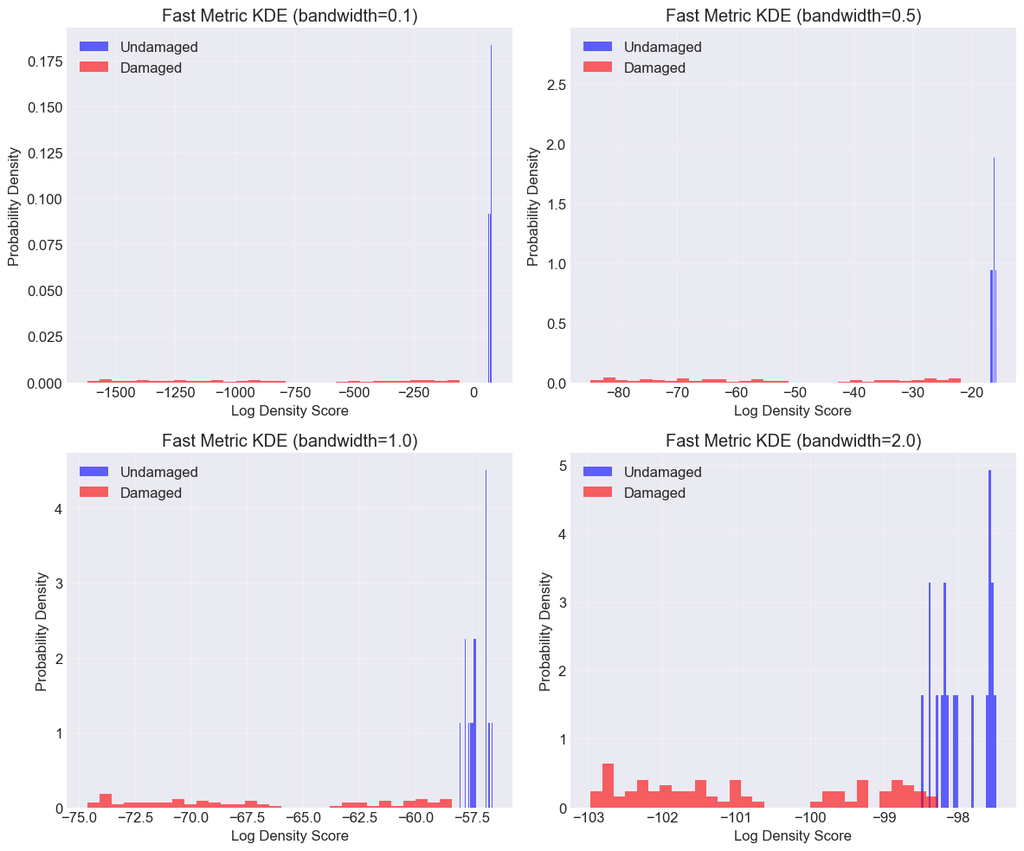

```python
# Create subplots for different bandwidths
fig, axes = plt.subplots(2, 2, figsize=(12, 10))
axes = axes.ravel()

for i, bw in enumerate(bandwidths):
    ax = axes[i]

    # Extract scores for undamaged and damaged
    scores = fast_scores[bw]
    undamaged_scores = scores[test_labels == 0]
    damaged_scores = scores[test_labels == 1]

    # Plot histograms
    ax.hist(undamaged_scores, bins=30, alpha=0.6, label='Undamaged',
            density=True, color='blue')
    ax.hist(damaged_scores, bins=30, alpha=0.6, label='Damaged',
            density=True, color='red')

    ax.set_xlabel('Log Density Score')
    ax.set_ylabel('Probability Density')
    ax.set_title(f'Fast Metric KDE (bandwidth={bw})')
    ax.legend()
    ax.grid(True, alpha=0.3)

plt.tight_layout()
plt.show()
```

## Threshold Selection and Classification

Select appropriate thresholds for damage detection.

```python
# Compute thresholds based on undamaged scores
confidence_level = 0.95
alpha = 1 - confidence_level

thresholds = {}
for bw in bandwidths:
    scores = fast_scores[bw]
    undamaged_scores = scores[test_labels == 0]
    thresholds[bw] = np.percentile(undamaged_scores, alpha * 100)
    print(f"Bandwidth {bw}: Threshold = {thresholds[bw]:.3f}")
```

```
Bandwidth 0.1: Threshold = 62.832
Bandwidth 0.5: Threshold = -17.544
Bandwidth 1.0: Threshold = -57.831
Bandwidth 2.0: Threshold = -98.390
```

## Performance Evaluation

Evaluate classification performance for different bandwidths.

```
Bandwidth 0.1:
  Accuracy: 0.990
  True Positive Rate: 1.000
  False Positive Rate: 0.056

Bandwidth 0.5:
  Accuracy: 0.990
  True Positive Rate: 1.000
  False Positive Rate: 0.056

Bandwidth 1.0:
  Accuracy: 0.990
  True Positive Rate: 1.000
  False Positive Rate: 0.056

Bandwidth 2.0:
  Accuracy: 0.980
  True Positive Rate: 0.988
  False Positive Rate: 0.056
```

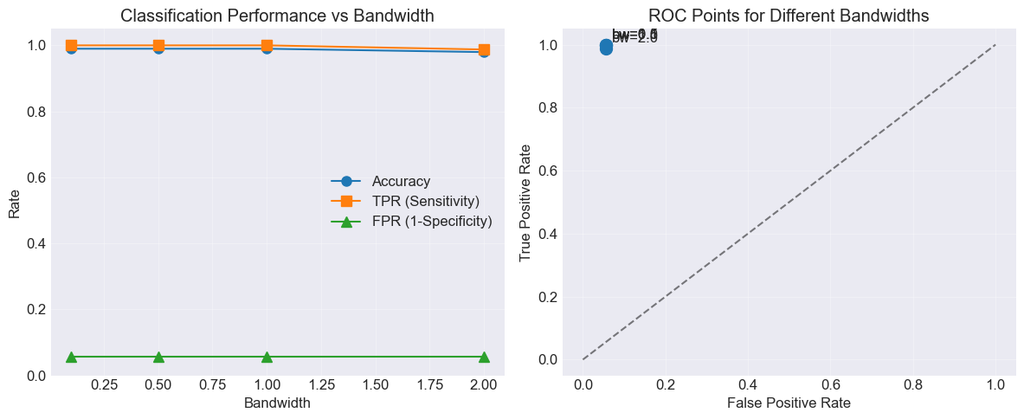

```python
# Compute classification metrics
from sklearn.metrics import classification_report, confusion_matrix

fig, axes = plt.subplots(1, 2, figsize=(12, 5))

# Performance metrics for each bandwidth
accuracies = []
tprs = []  # True positive rates
fprs = []  # False positive rates

for bw in bandwidths:
    scores = fast_scores[bw]
    threshold = thresholds[bw]

    # Classify: scores below threshold are damaged
    predictions = (scores < threshold).astype(int)

    # Compute metrics
    cm = confusion_matrix(test_labels, predictions)
    tn, fp, fn, tp = cm.ravel()

    accuracy = (tp + tn) / len(test_labels)
    tpr = tp / (tp + fn) if (tp + fn) > 0 else 0
    fpr = fp / (fp + tn) if (fp + tn) > 0 else 0

    accuracies.append(accuracy)
    tprs.append(tpr)
    fprs.append(fpr)

    print(f"\nBandwidth {bw}:")
    print(f"  Accuracy: {accuracy:.3f}")
    print(f"  True Positive Rate: {tpr:.3f}")
    print(f"  False Positive Rate: {fpr:.3f}")

# Plot performance vs bandwidth
ax1 = axes[0]
ax1.plot(bandwidths, accuracies, 'o-', label='Accuracy', markersize=8)
ax1.plot(bandwidths, tprs, 's-', label='TPR (Sensitivity)', markersize=8)
ax1.plot(bandwidths, fprs, '^-', label='FPR (1-Specificity)', markersize=8)
ax1.set_xlabel('Bandwidth')
ax1.set_ylabel('Rate')
ax1.set_title('Classification Performance vs Bandwidth')
ax1.legend()
ax1.grid(True, alpha=0.3)
ax1.set_ylim(0, 1.05)

# Plot ROC points
ax2 = axes[1]
ax2.plot(fprs, tprs, 'o-', markersize=10)
for i, bw in enumerate(bandwidths):
    ax2.annotate(f'bw={bw}', (fprs[i], tprs[i]),
                xytext=(5, 5), textcoords='offset points')
ax2.plot([0, 1], [0, 1], 'k--', alpha=0.5)
ax2.set_xlabel('False Positive Rate')
ax2.set_ylabel('True Positive Rate')
ax2.set_title('ROC Points for Different Bandwidths')
ax2.grid(True, alpha=0.3)
ax2.set_xlim(-0.05, 1.05)
ax2.set_ylim(-0.05, 1.05)

plt.tight_layout()
plt.show()
```

## Compare Different Distance Metrics

Evaluate performance with different distance metrics.

```python
# Test different metrics with optimal bandwidth
optimal_bw = 1.0  # Based on previous results
metrics = ['euclidean', 'manhattan', 'chebyshev']

metric_models = {}
metric_scores = {}
metric_performance = {}

for metric in metrics:
    print(f"\nTraining with {metric} metric...")

    # Train model
    metric_models[metric] = learn_fast_metric_kernel_density_shm(
        train_features, bw=optimal_bw, kernel='gaussian', metric=metric
    )

    # Score test data
    metric_scores[metric] = score_fast_metric_kernel_density_shm(
        test_features, metric_models[metric]
    )

    # Compute threshold and performance
    undamaged_scores = metric_scores[metric][test_labels == 0]
    threshold = np.percentile(undamaged_scores, alpha * 100)
    predictions = (metric_scores[metric] < threshold).astype(int)

    cm = confusion_matrix(test_labels, predictions)
    tn, fp, fn, tp = cm.ravel()

    metric_performance[metric] = {
        'accuracy': (tp + tn) / len(test_labels),
        'tpr': tp / (tp + fn) if (tp + fn) > 0 else 0,
        'fpr': fp / (fp + tn) if (fp + tn) > 0 else 0
    }

    print(f"  Accuracy: {metric_performance[metric]['accuracy']:.3f}")
    print(f"  TPR: {metric_performance[metric]['tpr']:.3f}")
    print(f"  FPR: {metric_performance[metric]['fpr']:.3f}")
```

```
Training with euclidean metric...
  Accuracy: 0.990
  TPR: 1.000
  FPR: 0.056

Training with manhattan metric...
  Accuracy: 0.990
  TPR: 1.000
  FPR: 0.056

Training with chebyshev metric...
  Accuracy: 0.969
  TPR: 0.975
  FPR: 0.056
```

## Visualize Metric Comparison

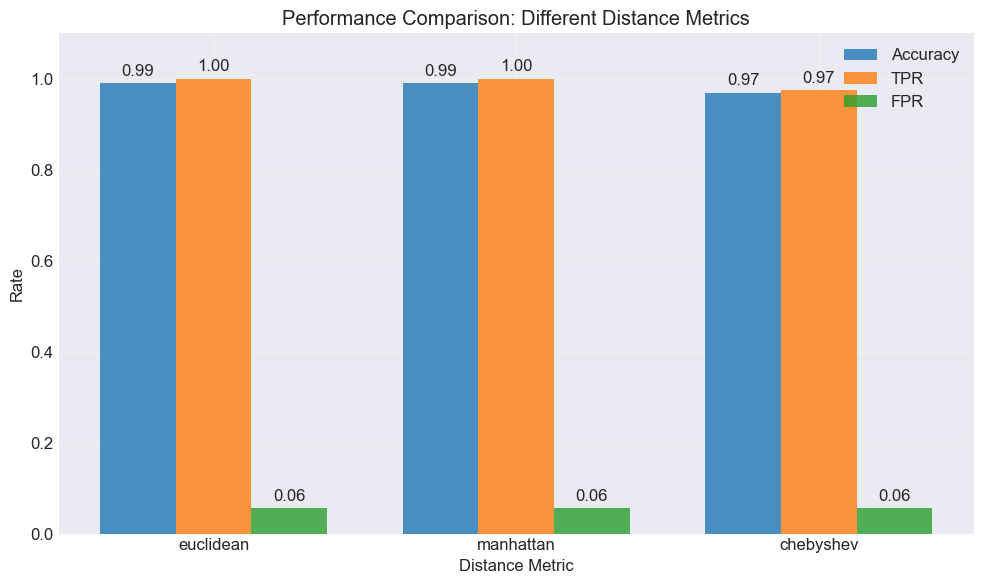

```python
# Create comparison bar plot
fig, ax = plt.subplots(figsize=(10, 6))

x = np.arange(len(metrics))
width = 0.25

accuracies = [metric_performance[m]['accuracy'] for m in metrics]
tprs = [metric_performance[m]['tpr'] for m in metrics]
fprs = [metric_performance[m]['fpr'] for m in metrics]

ax.bar(x - width, accuracies, width, label='Accuracy', alpha=0.8)
ax.bar(x, tprs, width, label='TPR', alpha=0.8)
ax.bar(x + width, fprs, width, label='FPR', alpha=0.8)

ax.set_xlabel('Distance Metric')
ax.set_ylabel('Rate')
ax.set_title('Performance Comparison: Different Distance Metrics')
ax.set_xticks(x)
ax.set_xticklabels(metrics)
ax.legend()
ax.grid(True, alpha=0.3)
ax.set_ylim(0, 1.1)

# Add value labels on bars
for i, (acc, tpr, fpr) in enumerate(zip(accuracies, tprs, fprs)):
    ax.text(i - width, acc + 0.01, f'{acc:.2f}', ha='center', va='bottom')
    ax.text(i, tpr + 0.01, f'{tpr:.2f}', ha='center', va='bottom')
    ax.text(i + width, fpr + 0.01, f'{fpr:.2f}', ha='center', va='bottom')

plt.tight_layout()
plt.show()
```

## Computational Efficiency Analysis

Analyze how fast metric KDE scales with dataset size.

```
Size 50: 0.001 seconds
Size 100: 0.001 seconds
Size 200: 0.001 seconds
Size 400: 0.001 seconds
Size 800: 0.001 seconds
```

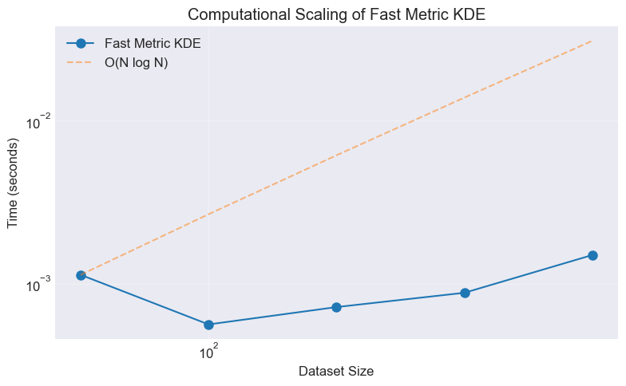

```python
# Test scaling with different dataset sizes
sizes = [50, 100, 200, 400, 800]
fast_times = []

for size in sizes:
    if size > len(train_features):
        # Generate synthetic data for larger sizes
        synthetic_data = np.random.randn(size, train_features.shape[1])
    else:
        synthetic_data = train_features[:size]

    # Time fast metric KDE
    start_time = time.time()
    model = learn_fast_metric_kernel_density_shm(synthetic_data, bw=1.0)
    _ = score_fast_metric_kernel_density_shm(synthetic_data[:10], model)
    elapsed = time.time() - start_time

    fast_times.append(elapsed)
    print(f"Size {size}: {elapsed:.3f} seconds")

# Plot scaling behavior
plt.figure(figsize=(8, 5))
plt.loglog(sizes, fast_times, 'o-', markersize=8, label='Fast Metric KDE')

# Add theoretical scaling lines
sizes_array = np.array(sizes)
fast_times_array = np.array(fast_times)
theoretical_nlogn = fast_times_array[0] * (sizes_array / sizes_array[0]) * np.log(sizes_array) / np.log(sizes_array[0])
plt.loglog(sizes, theoretical_nlogn, '--', alpha=0.5, label='O(N log N)')

plt.xlabel('Dataset Size')
plt.ylabel('Time (seconds)')
plt.title('Computational Scaling of Fast Metric KDE')
plt.legend()
plt.grid(True, alpha=0.3)
plt.tight_layout()
plt.show()
```

## Summary and Conclusions

### Practical Recommendations:

- **Use fast metric KDE** when dealing with large datasets (>1000 samples)
- **Optimize bandwidth** using cross-validation or grid search
- **Consider different metrics** based on feature characteristics
- **Monitor computational time** vs accuracy trade-offs

### Applications in SHM:

- Real-time damage detection with streaming data
- Large sensor networks with high-dimensional features
- Online learning scenarios requiring frequent model updates
- Multi-metric fusion for robust damage detection